# Tito on the map

Giorgio Comai

24 July 2017

## Preliminary remarks

This document should be considered draft until it is thoroughly verified. It may include substantial inaccuracies.

**[Click here to see all streets and squares dedicated to Tito identified by this script as an overlay on Google Maps](https://drive.google.com/open?id=1U7EqM2XDLHpyjJaEBy3inOETYg4&usp=sharing).**

As of 2017-07-24:

- Original OpenStreetMaps data repeated some data points multiple times. See this [overlay on Google Maps](https://www.google.com/maps/d/viewer?mid=1o575c8xb_TncaQ4Rk8NIxIyNpfY&ll=43.86474657972989%2C19.327976068483963&z=7) to get an idea. Data points with very similar coordinates (same coordinates until the first decimal) have been removed.
- Some streets may be missing: they may not be included in OpenStreetMaps, or I may have filtered them out my mistake. The data do not show any self-evident bias, but this does not mean they are correct.
- Mechanically querying Google Maps for each town in the region may offer more accurate results.
- Other ideas are welcome. Feel free to open an issue on the repository hosting this file https://github.com/giocomai/TitoOnTheMap/issues, or to get in touch via [Twitter](http://twitter.com/giocomai/).

**Update 2017-07-27: as anticipated, the verification of this map is progress ([see this map for partial updates](https://drive.google.com/open?id=1U7EqM2XDLHpyjJaEBy3inOETYg4&usp=sharing)). The figures presented below are inaccurate, as they substantially underestimate the total number of streets dedicated to Tito, at least is some areas. This document will be updated.**

## Getting OpenStreetMaps packages

Install Osmconvert and Osmfilter

```r
# osmosis not needed? (Osmosis)[http://wiki.openstreetmap.org/wiki/Osmosis/Installation]
# following code works on linux, for other OS see:
#  http://wiki.openstreetmap.org/wiki/Osmosis/Installation
dir.create(path = "osmosis", showWarnings = FALSE)

if (file.exists(file.path("osmosis", "osmosis-latest.tgz"))==FALSE) {
  download.file(url = "http://bretth.dev.openstreetmap.org/osmosis-build/osmosis-latest.tgz", destfile = file.path("osmosis", "osmosis-latest.tgz"))
  untar(tarfile = file.path("osmosis", "osmosis-latest.tgz"), exdir = "osmosis")
  system(command = "chmod a+x osmosis/bin/osmosis")
}
```

```r
# install osmfilter
if (file.exists("osmfilter")==FALSE) {
  system(command = "wget -O - http://m.m.i24.cc/osmfilter.c |cc -x c - -O3 -o osmfilter")
}

# install osmconvert
if (file.exists(file.path("osmconvert64"))==FALSE) {
  download.file(url = "http://m.m.i24.cc/osmconvert64", destfile = file.path("osmconvert64"))
  system(command = "chmod +x osmconvert64")
}
```

## Getting the data from OpenStreetMaps

Download all data for selected countries from [available repositories](http://download.geofabrik.de/europe.html).

```r
dir.create(path = "data", showWarnings = FALSE)
dir.create(path = file.path("data", "pbf"), showWarnings = FALSE)
countries <- c("slovenia", "croatia", "bosnia-herzegovina", "serbia", "montenegro", "kosovo", "macedonia")

for (i in countries) {
  if (file.exists(file.path("data", "pbf", paste0(i, "-latest.osm.pbf")))==FALSE) {
    download.file(url = paste0("http://download.geofabrik.de/europe/", i, "-latest.osm.pbf"), destfile = file.path("data", "pbf", paste0(i, "-latest.osm.pbf")))
  }
}
```

Filter only street names, and export them as CSV. (if anyone’s familiar with OSM, this is the place to check)

```r
# convert to a format that can be read by osmfilter, and remove author data to reduce file size
dir.create(path = file.path("data", "o5m"), showWarnings = FALSE)

for (i in countries) {
  if (file.exists(file.path("data", "o5m", paste0(i, "-latest.o5m")))==FALSE) {
    system(paste0('./osmconvert64 data/pbf/', i, '-latest.osm.pbf --drop-version --out-o5m -o=data/o5m/', i, '-latest.o5m'))
  }
}

# filter only streets
dir.create(path = file.path("data", "o5m-streets"), showWarnings = FALSE)

for (i in countries) {
  if (file.exists(file.path("data", "o5m-streets", paste0(i, "-streets.o5m")))==FALSE) {
    system(paste0('./osmfilter data/o5m/', i, '-latest.o5m --keep="highway=*" --drop-version > ', 'data/o5m-streets/', i, '-streets.o5m'))
  }
}

# export to csv only street type, name, and lon/lat

dir.create(path = file.path("data", "csv-streets"), showWarnings = FALSE)

for (i in countries) {
  if (file.exists(file.path("data", "csv-streets", paste0(i, "-streets.csv")))==FALSE) {
    system(paste0('./osmconvert64 data/o5m-streets/', i, '-streets.o5m --all-to-nodes --csv="@id @lat @lon highway name" > data/csv-streets/', i, '-streets.csv', " --csv-separator='; '"))
  }
}
```

## Keep only street names including reference to Tito, and presenting preliminary results

Criteria for filters:

- ends with ‘Tito’
- ends with ‘Tita’
- includes ‘Titov’
- includes ‘Тито’ (and accordingly, also all ‘Титов’, etc.)

```r
StreetsSummary <- data_frame(Country = countries, TotalStreets = as.integer(NA), TitoStreets = as.integer(NA))

FindTito <- "Tito$|Tita$|Titov|Титов|Тито"
tito_all <- data_frame()

for (i in countries) {
  # Import from csv
  temp_streets <- read_delim(file = file.path("data", "csv-streets", paste0(i, "-streets.csv")), delim = "; ", col_names = FALSE, locale = locale(decimal_mark = "."), trim_ws = TRUE)
  # Store total number of streets for each country
  StreetsSummary$TotalStreets[StreetsSummary$Country==i] <- nrow(temp_streets)
  # Filter only Tito's streets
  temp_tito <- temp_streets %>%
    filter(is.na(X5)==FALSE) %>%
    filter(stringr::str_detect(string = X5, pattern = stringr::regex(pattern = FindTito, ignore_case = TRUE))) %>%
    transmute(lat = X2, lon = X3, streetname = X5)  %>%
    # remove duplicate location with which have similar coordinates (same first decimal)
    mutate(lonShort = format(lon, digit = 3), latShort = format(lat, digit = 3)) %>%
    distinct(lonShort, latShort, .keep_all = TRUE) %>%
    select(-lonShort, -latShort) %>%
    mutate(country = i)
  # Store number of Tito's streets in given country
  StreetsSummary$TitoStreets[StreetsSummary$Country==i] <- nrow(temp_tito)
  # Merge table for each country
  tito_all <- bind_rows(tito_all, temp_tito)
}

# tito_all <- tito_all %>%
#   mutate(lonShort = format(lon, digit = 4), latShort = format(lat, digit = 4)) %>%
#   distinct(lonShort, latShort, .keep_all = TRUE) %>%
#   select(-lonShort, -latShort)

write_csv(x = tito_all %>% distinct(), path = "tito_coordinates.csv")
```

## Number of streets dedicated to Tito

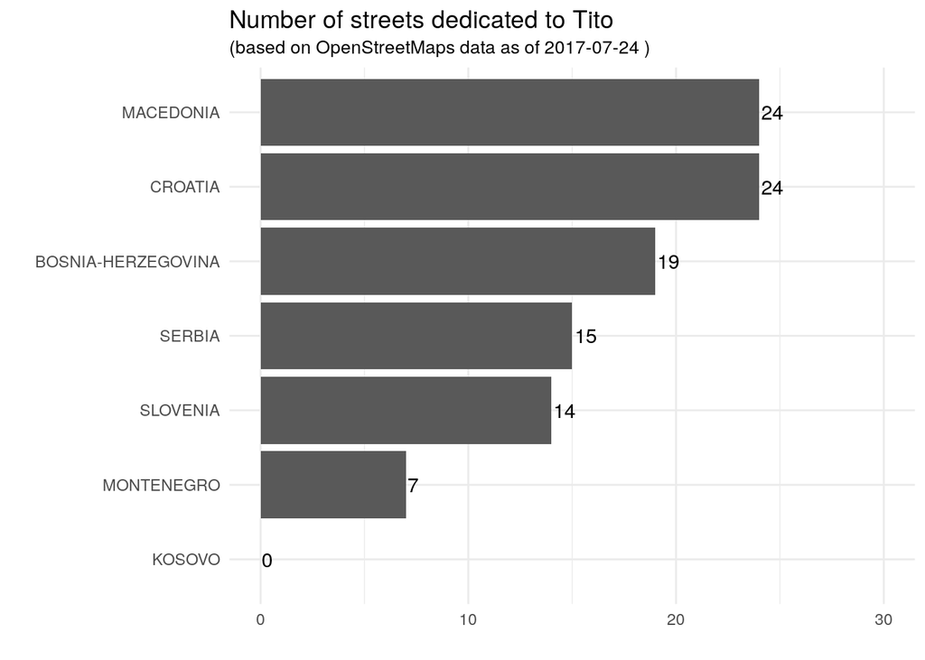

```r
StreetsSummary %>%
  arrange(TitoStreets) %>%
  mutate(Country = toupper(Country)) %>%
  mutate(Country = forcats::fct_inorder(Country)) %>%
  ggplot(aes(x = Country, y = TitoStreets, label = TitoStreets)) +
  geom_col() +
  scale_y_continuous(name = "", limits = c(0, 30)) +
  scale_x_discrete(name = "") +
  geom_text(hjust = -0.1) +
  coord_flip() +
  theme_minimal() +
  labs(title = "Number of streets dedicated to Tito", subtitle = paste("(based on OpenStreetMaps data as of", Sys.Date(), ")"))
```

## Share of streets dedicated to Tito

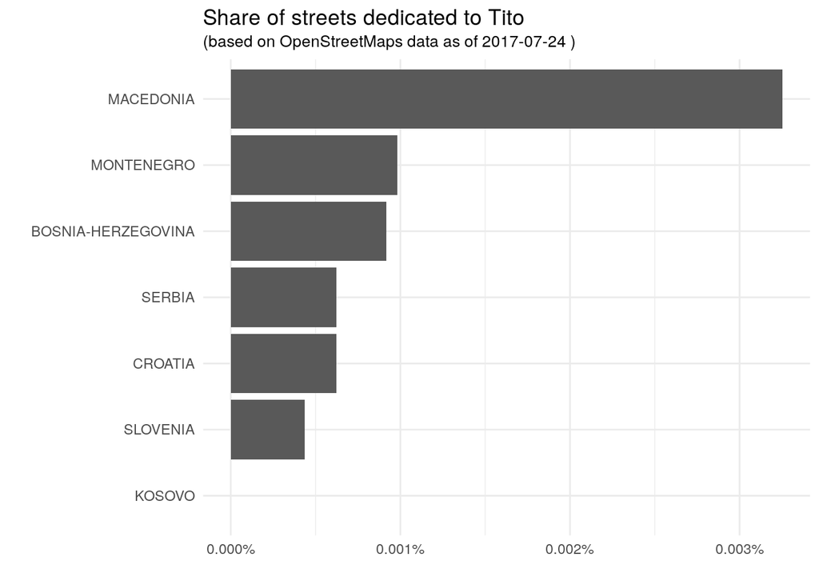

```r
options(scipen=999)
StreetsSummary %>%
  mutate(TitoShare = TitoStreets/TotalStreets) %>%
  arrange(TitoShare) %>%
  mutate(Country = toupper(Country)) %>%
  mutate(Country = forcats::fct_inorder(Country)) %>%
  ggplot(aes(x = Country, y = TitoShare, label = TitoShare)) +
  geom_col() +
  scale_y_continuous(name = "", labels = percent) +
  scale_x_discrete(name = "") +
  coord_flip() +
  theme_minimal() +
  labs(title = "Share of streets dedicated to Tito", subtitle = paste("(based on OpenStreetMaps data as of", Sys.Date(), ")"))
```

```r
knitr::kable(StreetsSummary %>% arrange(desc(TitoStreets)))
```

| Country | TotalStreets | TitoStreets |
| --- | --- | --- |
| croatia | 3862222 | 24 |
| macedonia | 737810 | 24 |
| bosnia-herzegovina | 2071858 | 19 |
| serbia | 2407281 | 15 |
| slovenia | 3213800 | 14 |
| montenegro | 713316 | 7 |
| kosovo | 666135 | 0 |

## Mark on the map streets dedicated to Tito

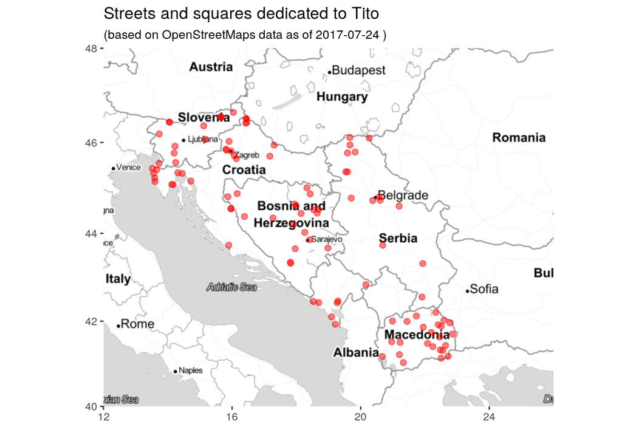

```r
# Setting the coordinates
wb <- c(left = 12, bottom = 40, right = 26, top = 48)

# Preparing the canvas
mapTonerLite <- get_stamenmap(bbox = wb, zoom = 6, maptype = "toner-lite") %>% ggmap()

mapTonerLite + geom_point(data=tito_all, aes(x=lon, y=lat), color="red", size=2, alpha=0.5) +
  labs(x = '', y = '') + labs(title = "Streets and squares dedicated to Tito", subtitle = paste("(based on OpenStreetMaps data as of", Sys.Date(), ")"))
```

[figure not shown]

```r
  ggsave("TitoTonerLight.png")

# Preparing the canvas
mapG <- get_googlemap("Sarajevo", scale = 2, zoom = 6) %>% ggmap()

mapG + geom_point(data=tito_all, aes(x=lon, y=lat), color="red", size=2, alpha=0.5) +
  labs(x = '', y = '') + labs(title = "Streets and squares dedicated to Tito", subtitle = paste("(based on OpenStreetMaps data as of", Sys.Date(), ")"))
```

```r
ggsave("TitoGmaps.png")


# # Preparing the canvas
# mapWatercolor <- get_stamenmap(bbox = wb, zoom = 7, maptype = "watercolor") %>% ggmap()
# # Adding the dots
# mapWatercolor + geom_point(data=tito_all, aes(x=lon, y=lat), color="red", size=2, alpha=0.5) +
#   labs(x = '', y = '') + ggtitle("Streets dedicated to Tito")
# ggsave("TitoWatercolor.png")
```

## Summary of all street names found

N.B. Check if something is missing and update criteria

```r
knitr::kable(tito_all %>% select(country, streetname) %>% group_by(country, streetname) %>% count() %>% arrange(country, desc(n), streetname))
```

| country | streetname | n |
| --- | --- | --- |
| bosnia-herzegovina | Maršala Tita | 11 |
| bosnia-herzegovina | Titova | 4 |
| bosnia-herzegovina | Titova ili Put Oficirske Škole | 1 |
| bosnia-herzegovina | Trg maršala Tita | 1 |
| bosnia-herzegovina | Ul Maršala Tita | 1 |
| bosnia-herzegovina | ul. Maršala Tita | 1 |
| croatia | Maršala Tita | 6 |
| croatia | Ulica Maršala Tita | 4 |
| croatia | Obala Maršala Tita | 2 |
| croatia | Titov trg | 2 |
| croatia | Hodaliste marsala tita | 1 |
| croatia | Josipa Broza Tita | 1 |
| croatia | Obala Josipa Broza Tita | 1 |
| croatia | Obala m. Tita | 1 |
| croatia | Poljana maršala Tita | 1 |
| croatia | Trg J. B. Tita | 1 |
| croatia | Trg maršala Tita | 1 |
| croatia | Trg Maršala Tita | 1 |
| croatia | Ulica Josipa Broza Tita | 1 |
| croatia | Ulica Josipa Broza-Tita | 1 |
| macedonia | Маршал Тито | 14 |
| macedonia | bul. Marsal Tito | 1 |
| macedonia | Marsal Tito | 1 |
| macedonia | Marshal Tito | 1 |
| macedonia | ul. Marshal Tito | 1 |
| macedonia | Кеј Маршал Тито | 1 |
| macedonia | Титова Митровачка | 1 |
| macedonia | Титовелешка | 1 |
| macedonia | Титово Ужице | 1 |
| macedonia | ул. Маршал Тито | 1 |
| macedonia | Улица Маршал Тито | 1 |
| montenegro | Marsala Tita | 2 |
| montenegro | Gjergj Kastrioti - Skënderbeu / Maršal Tito | 1 |
| montenegro | Josipa Broza Tita | 1 |
| montenegro | Maršala Tita | 1 |
| montenegro | Titove Korenice | 1 |
| montenegro | trg Maršala Tita | 1 |
| serbia | Maršala Tita | 5 |
| serbia | Титоградска | 4 |
| serbia | Aleja Maršala Tita | 1 |
| serbia | Marsala Tita | 1 |
| serbia | Ulica Marsala Tita | 1 |
| serbia | Ктитор | 1 |
| serbia | Тито Маршал | 1 |
| serbia | Титова | 1 |
| slovenia | Titova ulica | 3 |
| slovenia | Cesta maršala Tita | 2 |
| slovenia | Titova cesta | 2 |
| slovenia | Trg maršala Tita | 2 |
| slovenia | Titov most | 1 |
| slovenia | Titov trg | 1 |
| slovenia | Titov trg / Piazza Tito | 1 |
| slovenia | Titova - Nasipna | 1 |
| slovenia | Ulica Josipa Broza-Tita | 1 |

```r
write_csv(x = tito_all %>% select(country, streetname) %>% group_by(country, streetname) %>% count() %>% arrange(country, desc(n), streetname), path = "tito_streetnames.csv")
```

## About the author

Giorgio Comai is on [Twitter](http://twitter.com/giocomai/). His website is https://giorgiocomai.eu/